# WerdenEtAl2019_Analysis

### Compare source limitation between treatments

- Test for station-level source limitation<sub>ref</sub>among all treatments using mixed-effects one-way ANOVA (species RE)

```r
# filter out for focal species
seedRain_sourceLimitationCalcs_filter <- seedRain_sourceLimitationCalcs %>%
                                           filter(Species %in% speciesList_seedlings_tenPercentSeedTreat$Species[speciesList_seedlings_tenPercentSeedTreat$Treatment == "C"]
                                                  & Treatment == "C" |
                                                  Species %in% speciesList_seedlings_tenPercentSeedTreat$Species[speciesList_seedlings_tenPercentSeedTreat$Treatment == "I"]
                                                  & Treatment == "I" |
                                                  Species %in% speciesList_seedlings_tenPercentSeedTreat$Species[speciesList_seedlings_tenPercentSeedTreat$Treatment == "P"]
                                                  & Treatment == "P" |
                                                  Species %in% speciesList_seedlings_tenPercentSeedTreat$Species[speciesList_seedlings_tenPercentSeedTreat$Treatment == "R"]
                                                  & Treatment == "R")


##  anovas
sourceLimitMod <- lmer(sourceLimitation~Treatment + (1|Species), seedRain_sourceLimitationCalcs_filter)
Anova(sourceLimitMod, type = "II")
```

```
## Analysis of Deviance Table (Type II Wald chisquare tests)
##
## Response: sourceLimitation
##            Chisq Df Pr(>Chisq)
## Treatment 8.9246  3    0.03031 *
## ---
## Signif. codes:  0 '***' 0.001 '**' 0.01 '*' 0.05 '.' 0.1 ' ' 1
```

```r
sourceLim.emm <- emmeans(sourceLimitMod, pairwise ~ Treatment)
CLD(sourceLim.emm)
```

```
##  Treatment emmean     SE   df lower.CL upper.CL .group
##  R          0.186 0.0371 90.2    0.113    0.260  1
##  P          0.237 0.0367 80.3    0.164    0.310  12
##  I          0.245 0.0356 72.2    0.174    0.316  12
##  C          0.290 0.0376 86.3    0.215    0.365   2
##
## Degrees-of-freedom method: kenward-roger
## Confidence level used: 0.95
## P value adjustment: tukey method for comparing a family of 4 estimates
## significance level used: alpha = 0.05
```

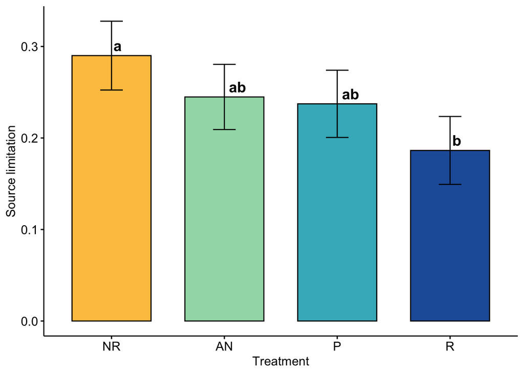

```r
# make CLD for figure
obsTreat_sig <- c("a", "ab", "ab", "b")

# plot the seed limitation as just mean bars instead
plot.sourceLim.emm <- tidy(sourceLim.emm$emmeans)

fig3D <- ggbarplot(plot.sourceLim.emm,
                      x = "Treatment",
                      y = "estimate",
                      fill = "Treatment",
                      palette =CB_YlGnBu,
                      xlab = "Treatment",
                      ylab = "Source limitation",
                      legend = "none")+
                      geom_errorbar(aes(ymin=estimate-std.error, ymax=estimate+std.error),
                                     width=.2,                    # Width of the error bars
                                     position=position_dodge(.9))+
                      geom_text(aes(x = Treatment, y = estimate, label = obsTreat_sig),
                                vjust=-.45,
                                hjust=-.28,
                                fontface = "bold",
                                size = 5)+
                      scale_x_discrete(labels = c("NR", "AN", "P", "R"))
fig3D
```

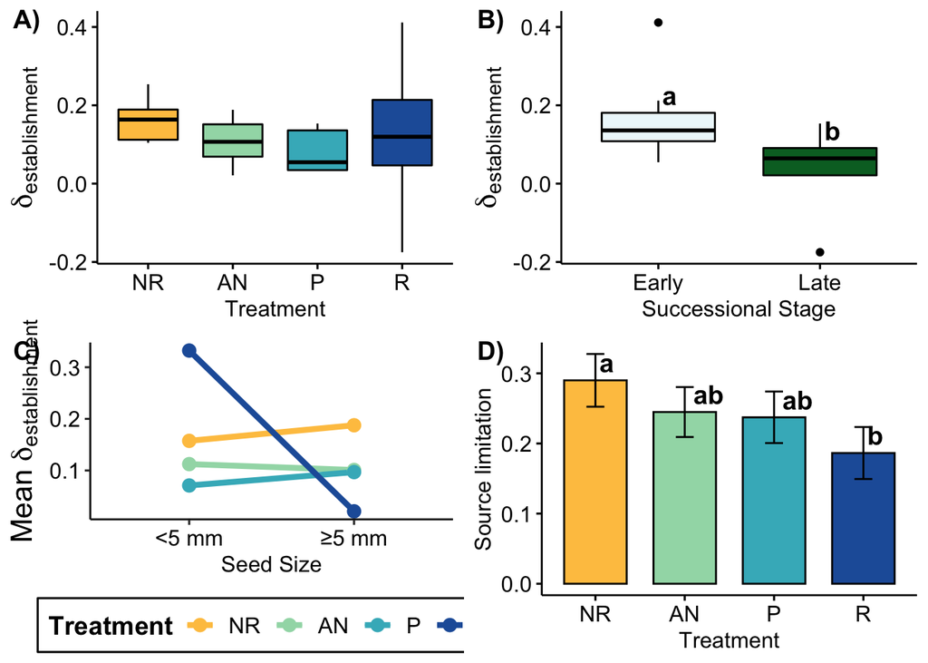

```r
Figure3 <- ggarrange(fig3A, fig3B, fig3C, fig3D, labels = c("A)", "B)", "C)", "D)"), ncol = 2, nrow = 2)
Figure3
```

```r
ggsave("Figure3.pdf", width = 9, height = 9, units = "in", dpi = 600, device = cairo_pdf)
```

### Make figure S2

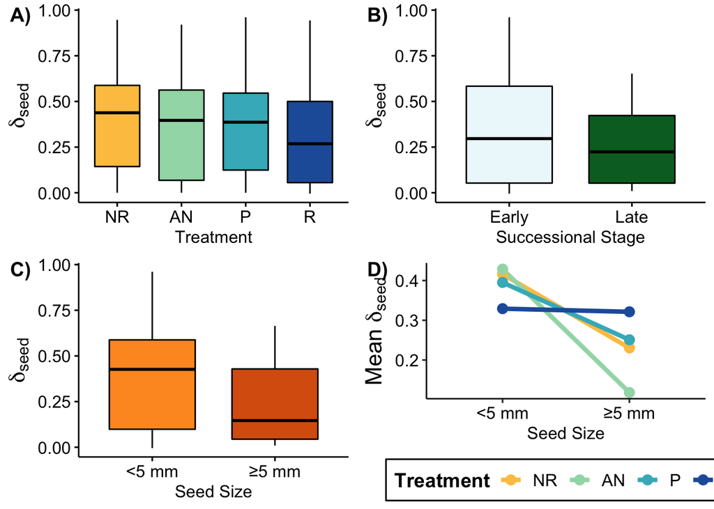

```r
# save
FigureS2 <- ggarrange(fig2A_Seed, fig2B_Seed, fig2C_Seed, figS2D_interact, labels = c("A)", "B)", "C)", "D)"), ncol = 2, nrow = 2)
FigureS2
```

```r
ggsave("FigureS2.pdf", width = 9, height = 9, units = "in", dpi = 600, device = cairo_pdf)
```

## Seed-to-seedling transition modeling – answering Question 1 in manuscript

The following models the STS (seed-to-seedling) transition across the treatments using a Bayesian regression approach

### Organize seed and seedling data on ‘station’ level STS modeling

- Data are filtered to only include species that occurred at >=10% of stations on a treatment basis as with Q2 randomizations
- Final modeling data frame “seedsAndSeedlings_forModeling_final” includes all predictors used for modeling (e.g., restoration treatments, seed size, percent canopy cover, dispersal syndrome) as well as seed deposition scaled to whole plot area as with establishment limitation calculations to use as offset when predicting rates of STS

```r
# seed rain organize at station level
seedRain_All_byTreat_model <- seedrainWorking %>%
                              # only use trees
                              filter(Growthform %in% c("CT", "UT")) %>%
                              # group by Site, Treatment, island size (Isize), Station (plot), and Species
                              group_by(Site, Treatment, Isize, Plot, Species) %>%
                              # sum seeds at station level
                              summarize(seedsSum=sum(SR, na.rm = TRUE)) %>%
                              # create presence absence seed column
                              mutate(present = ifelse(seedsSum>0, "1", "0"))

seedRain_All_byTreat_model$present <- as.numeric(seedRain_All_byTreat_model$present)

# seedlings organize at station level
seedlingsAll_byTreat_model <- recruitmentWorking %>%
                              # only use trees
                              filter(Growthform %in% c("CT", "UT")) %>%
                              filter(site %in% c("BB", "EC", "JG", "MM", "SG")) %>% # only use sites where SR was monitored continuously
                              filter(isz %in% c(NA, "M", "L")) %>% # remove small island sampling plots where seed traps were not placed
                              # only include years where seed traps were sampled
                              filter(year %in% c("2014", "2015", "2016", "2017")) %>%
                              # group by Site, Treatment, island size (Isize), Station (plot), and Species
                              group_by(site, treat, isz, FQ, spec) %>%
                              # sum seedlings at station level
                              summarize(count = n()) %>%
                              # create presence absence seedling column
                              mutate(present = as.numeric(ifelse(count>0, "1", "0")))

seedlingsAll_byTreat_model <- droplevels(seedlingsAll_byTreat_model)

# rename columns for combination of seeds and seedlings
names(seedlingsAll_byTreat_model)[1] <- "Site"
names(seedlingsAll_byTreat_model)[2] <- "Treatment"
names(seedlingsAll_byTreat_model)[3] <- "Isize"
names(seedlingsAll_byTreat_model)[5] <- "Species"
names(seedlingsAll_byTreat_model)[4] <- "Plot"
names(seedlingsAll_byTreat_model)[6] <- "count_seedling"
names(seedlingsAll_byTreat_model)[7] <- "present_seedling"
names(seedRain_All_byTreat_model)[7] <- "present_seeds"

# join seeds and seedlings
seedsAndSeedlings_ByPlot_all <- full_join(seedRain_All_byTreat_model, seedlingsAll_byTreat_model, by = c("Site", "Treatment", "Isize", "Plot", "Species"))
seedsAndSeedlings_ByPlot_all <- as.data.frame(seedsAndSeedlings_ByPlot_all)
seedsAndSeedlings_ByPlot_all$Species <- as.factor(seedsAndSeedlings_ByPlot_all$Species)

# convert all NAs to 0 for present_seeds, count_seedling, and present_seedling
seedsAndSeedlings_ByPlot_all$present_seeds[is.na(seedsAndSeedlings_ByPlot_all$present_seeds)] <- 0
seedsAndSeedlings_ByPlot_all$count_seedling[is.na(seedsAndSeedlings_ByPlot_all$count_seedling)] <- 0
seedsAndSeedlings_ByPlot_all$present_seedling[is.na(seedsAndSeedlings_ByPlot_all$present_seedling)] <- 0

#------
# make final df for models "seedsAndSeedlings_forModeling"
# data are filtered to only include species that occured at >=10% of stations on a treatment basis as with randomizations
# this df also includes seed deposition scaled to whole plot area as with establishment limitation calculations
seedsAndSeedlings_forModeling <- seedsAndSeedlings_ByPlot_all %>%
                                # only use species occuring as seed in >=10% of stations on a treatment basis
                                filter(Species %in% speciesList_seedlings_tenPercentSeedTreat$Species[speciesList_seedlings_tenPercentSeedTreat$Treatment == "C"] & Treatment == "C" |
                                Species %in% speciesList_seedlings_tenPercentSeedTreat$Species[speciesList_seedlings_tenPercentSeedTreat$Treatment == "I"] & Treatment == "I" |
                                Species %in% speciesList_seedlings_tenPercentSeedTreat$Species[speciesList_seedlings_tenPercentSeedTreat$Treatment == "P"] & Treatment == "P" |
                                Species %in% speciesList_seedlings_tenPercentSeedTreat$Species[speciesList_seedlings_tenPercentSeedTreat$Treatment == "R"] & Treatment == "R") %>%
                                # create column for seed/seedling presence = 1 when both seeds/seeldings present, or just seedlings present
                                # this removes instances where there are seedings but no seeds (sensu Muscarella et al. 2013)
                                mutate(filteringCat = ifelse(present_seeds == 1 & present_seedling == 1 | present_seeds == 1 & present_seedling == 0, 1, 0)) %>%
                                # use only species occuring as both seeds/seedling
                                filter(filteringCat == 1) %>%
                                # scale the seeds up to make plots comparable
                                mutate(seedsSum_scaled = NA) %>%
                                # 10.67x larger area than traps in controls, plantation, reference
                                mutate(seedsSum_scaled = ifelse(Treatment == "C" | Treatment == "P" | Treatment == "R", (seedsSum*10.67), seedsSum_scaled)) %>%
                                # 13.33x larger area in medium islands
                                mutate(seedsSum_scaled = ifelse(Treatment == "I" & Isize == "M", (seedsSum*13.33), seedsSum_scaled)) %>%
                                # 16x larger area in medium islands in large islands
                                mutate(seedsSum_scaled = ifelse(Treatment == "I" & Isize == "L", (seedsSum*16), seedsSum_scaled))

#-----
# add vegetation cover and species trait data
# join with vegetation data
seedsAndSeedlings_forModeling_vegData <- inner_join(seedsAndSeedlings_forModeling, vegStructureSummary, by = c("Site", "Treatment", "Plot"))
# join with trait data
seedsAndSeedlings_forModeling_final <- inner_join(seedsAndSeedlings_forModeling_vegData, islasTraits, by = "Species")
# fix data types
seedsAndSeedlings_forModeling_final$Site <- as.factor(seedsAndSeedlings_forModeling_final$Site)
seedsAndSeedlings_forModeling_final$Species <- as.factor(seedsAndSeedlings_forModeling_final$Species)
seedsAndSeedlings_forModeling_final$seedsSum <- as.numeric(seedsAndSeedlings_forModeling_final$seedsSum)
seedsAndSeedlings_forModeling_final$SeedSize <- as.factor(seedsAndSeedlings_forModeling_final$SeedSize)


# recode seed size to put larger categories into category "2" -- So, "1" = <5mm; "2" = >=5mm
seedsAndSeedlings_forModeling_final$SeedSize[seedsAndSeedlings_forModeling_final$SeedSize == "3" |
                                                                 seedsAndSeedlings_forModeling_final$SeedSize == "4"] <- "2"
seedsAndSeedlings_forModeling_final <- droplevels(seedsAndSeedlings_forModeling_final)
```

### Standardization and treatment leveling

- Standardizes continuous predictors (percent canopy cover) using z-transformation
- Code reference forests, wind-dispersed seeds, and seeds <5 mm as first levels of factors so coefficients will be reported relative to those factor levels.

```r
# standardize percent canopy cover meaurements
seedsAndSeedlings_forModeling_final_standard <- seedsAndSeedlings_forModeling_final
seedsAndSeedlings_forModeling_final_standard$meanCover <- with(seedsAndSeedlings_forModeling_final_standard, (meanCover - mean(meanCover))/(2*sd(meanCover)))

# make the the referen the "dummy" or "reference" level
seedsAndSeedlings_forModeling_final_standard$Treatment_Ref <- relevel(seedsAndSeedlings_forModeling_final_standard$Treatment, ref=4)
```

### Fit the full STS model with all predictors

The code below implements the Bayesian hierarchical regression for the STS model as explained in the manuscript: We built a generalized linear mixed-model using the number of seedling recruits at a sampling station as the response. We included the log of seeds (scaled to the sampling area for seedlings as with seed and establishment limitation calculations) that arrived at a station as an offset, which directly models the STS as the rate of seedlings recruiting at a sampling station per the number of seeds arriving at that station (Muscarella et al. 2013). Experimental treatments (natural regeneration, applied nucleation, plantation, reference forest), mean % canopy cover at sampling stations, and the life-history traits of each species (dispersal syndrome, seed size) were included as fixed effects predictors. Species and site were included as random effects.

Additional information on approach to model fitting from the manuscript: In initial STS models, we used a Poisson error distribution and residuals were overdispersed. We also determined that the seedling recruit data were zero-inflated (see score-test below). To account for this in the final models we used a zero-inflated logit distribution to account for excess zeros and a negative binomial error distribution to model seed-to-seedling transitions. All coefficients were estimated using non-informative priors with Stan in R. The model converged with R-hat values <=1.01 for all parameters. We considered individual predictors as significant if the 95% credible intervals of an estimated coefficient did not overlap zero.

```r
#----
# first check assumptions for choice of distributions
# test for zero-inflation with score test shows seedling data are highly zero inflated = used zero-inflated error dist.
zero.test(seedsAndSeedlings_forModeling_final_standard$count_seedling)
```

```
## Score test for zero inflation
##
##      Chi-square = 1368.42972
##      df = 1
##      pvalue: < 2.22e-16
```

```r
# histogram and box plot indicates zero-inflation and over-dispersion (clumped observations)
# likely poisson is not best choice but compare zero-inflated poisson with zero-inflated negative binomial below
#hist(seedsAndSeedlings_forModeling_final_standard$count_seedling)
#boxplot(seedsAndSeedlings_forModeling_final_standard$count_seedling, horizontal=TRUE)
#rug(jitter(seedsAndSeedlings_forModeling_final_standard$count_seedling))

#---
# set Stan parameters for modeling
# specify C++14 standard to compile Stan programs
Sys.setenv(USE_CXX14 = 1)

# run fits in parallel
rstan_options(auto_write = TRUE)
options(mc.cores = parallel::detectCores())

#---
# fit full model with all predictors: zero-inflated poisson error dist.
poissonZI_STS <- brm(count_seedling ~ Treatment_Ref + meanCover + Dispersalmode + SeedSize +
                                           offset(log(seedsSum_scaled)) + (1| Species) + (1|Site), # STS as the rate of recruits/seeds at station
                                           data = seedsAndSeedlings_forModeling_final_standard,
                                           family = zero_inflated_poisson(link = "log", link_zi = "logit"), # using zero-inflated poisson
                                           prior = c(set_prior("normal(0, 1e6)", class = "b"), # non-informative priors for predictors
                                           set_prior("normal(0, 1e6)", class = "Intercept")), # non-informative priors for intercept
                                           control = list(adapt_delta = .99) # decrease divergent transitions
                                           )
# Warnings: possible fit issue indicated, 47 transitions exceed max. treedepth when first run
# summary -- all converged @ R-hat = 1 except for seedSize = 1.01 ...not ideal, compare with negative binomial error dist. below
summary(poissonZI_STS)
```

```
##  Family: zero_inflated_poisson
##   Links: mu = log; zi = identity
## Formula: count_seedling ~ Treatment_Ref + meanCover + Dispersalmode + SeedSize + offset(log(seedsSum_scaled)) + (1 | Species) + (1 | Site)
##    Data: seedsAndSeedlings_forModeling_final_standard (Number of observations: 1184)
## Samples: 4 chains, each with iter = 2000; warmup = 1000; thin = 1;
##          total post-warmup samples = 4000
##
## Group-Level Effects:
## ~Site (Number of levels: 5)
##               Estimate Est.Error l-95% CI u-95% CI Rhat Bulk_ESS Tail_ESS
## sd(Intercept)     0.85      0.54     0.32     2.29 1.00     1334     2267
##
## ~Species (Number of levels: 45)
##               Estimate Est.Error l-95% CI u-95% CI Rhat Bulk_ESS Tail_ESS
## sd(Intercept)     3.51      0.63     2.53     4.98 1.00     1019     1972
##
## Population-Level Effects:
##                  Estimate Est.Error l-95% CI u-95% CI Rhat Bulk_ESS Tail_ESS
## Intercept          -12.45      1.89   -16.45    -9.05 1.00     1193     1595
## Treatment_RefC       0.51      0.33    -0.13     1.16 1.00     1609     2376
## Treatment_RefI      -0.01      0.31    -0.59     0.62 1.00     1690     2244
## Treatment_RefP      -0.08      0.33    -0.71     0.56 1.00     1837     2504
## meanCover            0.20      0.27    -0.32     0.76 1.00     4235     3131
## DispersalmodeZOO     3.63      1.83     0.15     7.52 1.00     1320     1720
## SeedSize2            3.88      1.38     1.23     6.67 1.01      659     1397
##
## Family Specific Parameters:
##    Estimate Est.Error l-95% CI u-95% CI Rhat Bulk_ESS Tail_ESS
## zi     0.43      0.04     0.35     0.51 1.00     4208     2820
##
## Samples were drawn using sampling(NUTS). For each parameter, Eff.Sample
## is a crude measure of effective sample size, and Rhat is the potential
## scale reduction factor on split chains (at convergence, Rhat = 1).
```

```r
# visually check posterior samples - chains not particularly well mixed (commented out below to run knit pdf)
#launch_shinystan(poissonZI_STS)


#---
# fit full model with all predictors: zero-inflated negative binomial error dist.
finalModSTS_forFigS2 <- brm(count_seedling ~ Treatment_Ref + meanCover + Dispersalmode + SeedSize +
                            offset(log(seedsSum_scaled)) + (1|Species) + (1|Site), # model STS as the rate of recruits/seeds at a station with all predictors
                            data = seedsAndSeedlings_forModeling_final_standard,
                            family = zero_inflated_negbinomial(link = "log", link_shape = "log", link_zi = "logit"), # zero-inflated neg. binom.
                            prior = c(set_prior("normal(0, 1e6)", class = "b"), # non-informative priors for predictors
                            set_prior("normal(0, 1e6)", class = "Intercept")), # non-informative priors for intercept
                            control = list(adapt_delta = .99), # decrease divergent transitions
                            chains=4, iter=5000, warmup=2500, thin=5
                            )
# summary -- all converged @ Rhat = 1.0
summary(finalModSTS_forFigS2)
```

```
##  Family: zero_inflated_negbinomial
##   Links: mu = log; shape = identity; zi = identity
## Formula: count_seedling ~ Treatment_Ref + meanCover + Dispersalmode + SeedSize + offset(log(seedsSum_scaled)) + (1 | Species) + (1 | Site)
##    Data: seedsAndSeedlings_forModeling_final_standard (Number of observations: 1184)
## Samples: 4 chains, each with iter = 5000; warmup = 2500; thin = 5;
##          total post-warmup samples = 2000
##
## Group-Level Effects:
## ~Site (Number of levels: 5)
##               Estimate Est.Error l-95% CI u-95% CI Rhat Bulk_ESS Tail_ESS
## sd(Intercept)     1.37      0.85     0.52     3.41 1.00     1910     1933
##
## ~Species (Number of levels: 45)
##               Estimate Est.Error l-95% CI u-95% CI Rhat Bulk_ESS Tail_ESS
## sd(Intercept)     3.75      0.66     2.66     5.23 1.00     1527     1854
##
## Population-Level Effects:
##                  Estimate Est.Error l-95% CI u-95% CI Rhat Bulk_ESS Tail_ESS
## Intercept          -14.44      2.17   -19.04   -10.52 1.00     1830     1773
## Treatment_RefC       1.86      0.59     0.74     3.02 1.00     2131     1848
## Treatment_RefI       1.52      0.50     0.58     2.49 1.00     2043     2053
## Treatment_RefP       1.32      0.51     0.32     2.31 1.00     2072     1855
## meanCover            0.66      0.42    -0.17     1.50 1.00     2097     2103
## DispersalmodeZOO     4.00      1.98     0.31     8.05 1.00     1763     1986
## SeedSize2            4.64      1.44     1.91     7.60 1.00     1625     1878
##
## Family Specific Parameters:
##       Estimate Est.Error l-95% CI u-95% CI Rhat Bulk_ESS Tail_ESS
## shape     0.36      0.08     0.25     0.56 1.00     1994     1951
## zi        0.09      0.07     0.00     0.25 1.00     1929     1932
##
## Samples were drawn using sampling(NUTS). For each parameter, Eff.Sample
## is a crude measure of effective sample size, and Rhat is the potential
## scale reduction factor on split chains (at convergence, Rhat = 1).
```

```r
# visually check posterior samples - chains are well mixed and diagnostics all ok (commented out below to run knit pdf)
#launch_shinystan(finalModSTS_forFigS2)


#---
# model accounting for zero-inflation/overdispersion (finalModSTS_forFigS2) has better fit according to WAIC than zero-inflated poisson (poissonZI_STS)
waic(poissonZI_STS, finalModSTS_forFigS2) #finalModSTS_forFigS2 has much lower WAIC as well indiciting better fit
```

```
## Output of model 'poissonZI_STS':
##
## Computed from 4000 by 1184 log-likelihood matrix
##
##           Estimate    SE
## elpd_waic   -785.3  79.5
## p_waic       134.7  29.3
## waic        1570.6 159.1
##
## 58 (4.9%) p_waic estimates greater than 0.4. We recommend trying loo instead.
##
## Output of model 'finalModSTS_forFigS2':
##
## Computed from 2000 by 1184 log-likelihood matrix
##
##           Estimate   SE
## elpd_waic   -566.9 39.7
## p_waic        37.9  6.2
## waic        1133.8 79.4
##
## 23 (1.9%) p_waic estimates greater than 0.4. We recommend trying loo instead.
##
## Model comparisons:
##                      elpd_diff se_diff
## finalModSTS_forFigS2    0.0       0.0
## poissonZI_STS        -218.4      53.6
```

```r
# Comparison of model wreights with WAIC and LOO both show zero-inflated neg. binom. is best
model_weights(poissonZI_STS, finalModSTS_forFigS2, weights = "waic") # compare models weights w/ WAIC
```

```
##        poissonZI_STS finalModSTS_forFigS2
##         1.449272e-95         1.000000e+00
```

```r
model_weights(poissonZI_STS, finalModSTS_forFigS2, weights = "loo")  # compare models weights w/ LOO
```

```
##        poissonZI_STS finalModSTS_forFigS2
##         4.298975e-96         1.000000e+00
```

```r
#---
# final diagnostics and summaries of final model (finalModSTS_forFigS2) which uses zero-inflated neg. binom. error dist.

# Stan code for reproducibility
# stancode(finalModSTS_forFigS2)

# summary -- all converged @ Rhat = 1.0
summary(finalModSTS_forFigS2)
```

```
##  Family: zero_inflated_negbinomial
##   Links: mu = log; shape = identity; zi = identity
## Formula: count_seedling ~ Treatment_Ref + meanCover + Dispersalmode + SeedSize + offset(log(seedsSum_scaled)) + (1 | Species) + (1 | Site)
##    Data: seedsAndSeedlings_forModeling_final_standard (Number of observations: 1184)
## Samples: 4 chains, each with iter = 5000; warmup = 2500; thin = 5;
##          total post-warmup samples = 2000
##
## Group-Level Effects:
## ~Site (Number of levels: 5)
##               Estimate Est.Error l-95% CI u-95% CI Rhat Bulk_ESS Tail_ESS
## sd(Intercept)     1.37      0.85     0.52     3.41 1.00     1910     1933
##
## ~Species (Number of levels: 45)
##               Estimate Est.Error l-95% CI u-95% CI Rhat Bulk_ESS Tail_ESS
## sd(Intercept)     3.75      0.66     2.66     5.23 1.00     1527     1854
##
## Population-Level Effects:
##                  Estimate Est.Error l-95% CI u-95% CI Rhat Bulk_ESS Tail_ESS
## Intercept          -14.44      2.17   -19.04   -10.52 1.00     1830     1773
## Treatment_RefC       1.86      0.59     0.74     3.02 1.00     2131     1848
## Treatment_RefI       1.52      0.50     0.58     2.49 1.00     2043     2053
## Treatment_RefP       1.32      0.51     0.32     2.31 1.00     2072     1855
## meanCover            0.66      0.42    -0.17     1.50 1.00     2097     2103
## DispersalmodeZOO     4.00      1.98     0.31     8.05 1.00     1763     1986
## SeedSize2            4.64      1.44     1.91     7.60 1.00     1625     1878
##
## Family Specific Parameters:
##       Estimate Est.Error l-95% CI u-95% CI Rhat Bulk_ESS Tail_ESS
## shape     0.36      0.08     0.25     0.56 1.00     1994     1951
## zi        0.09      0.07     0.00     0.25 1.00     1929     1932
##
## Samples were drawn using sampling(NUTS). For each parameter, Eff.Sample
## is a crude measure of effective sample size, and Rhat is the potential
## scale reduction factor on split chains (at convergence, Rhat = 1).
```

```r
# visually check posterior samples - chains are well mixed and diagnostics all ok (commented out below to run knit pdf)
#launch_shinystan(finalModSTS_forFigS2)

# look at summary of sampler output: no divergent transitions and acceptance probability is high
summary(do.call(rbind, args = get_sampler_params(finalModSTS_forFigS2$fit, inc_warmup = FALSE)), digits = 2)
```

```
##  accept_stat__    stepsize__     treedepth__   n_leapfrog__  divergent__
##  Min.   :0.20   Min.   :0.018   Min.   :6.0   Min.   : 63   Min.   :0
##  1st Qu.:0.98   1st Qu.:0.026   1st Qu.:7.0   1st Qu.:127   1st Qu.:0
##  Median :0.99   Median :0.031   Median :7.0   Median :127   Median :0
##  Mean   :0.99   Mean   :0.031   Mean   :7.1   Mean   :163   Mean   :0
##  3rd Qu.:1.00   3rd Qu.:0.036   3rd Qu.:7.0   3rd Qu.:255   3rd Qu.:0
##  Max.   :1.00   Max.   :0.042   Max.   :8.0   Max.   :511   Max.   :0
##     energy__
##  Min.   :729
##  1st Qu.:753
##  Median :759
##  Mean   :759
##  3rd Qu.:765
##  Max.   :787
```

```r
# bayes R^2 = 0.51
bayes_R2(finalModSTS_forFigS2)
```

```
##     Estimate   Est.Error    Q2.5     Q97.5
## R2 0.5074905 0.003881534 0.50146 0.5162425
```